# Universidad de Costa Rica

Bancos Privados Costarricenses

Fiorella Laurito Torres

# Pronósticos Carteras Crediticias

## Introducción

Entorno histórico del banco

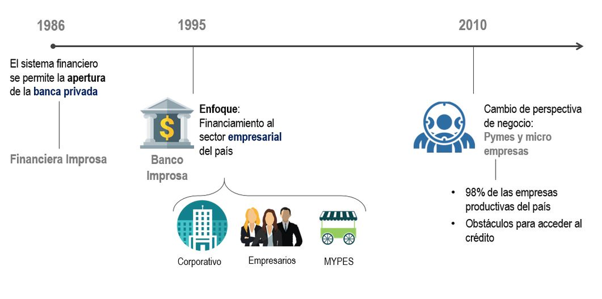

## Objetivo de Investigación

> Pronosticar el comportamiento de la cartera crediticia del banco de Octubre 2018 a Diciembre 2019, para así obtener una perspectiva del otorgamiento de créditos a micro, pequeño y medianas empresas, posibles búsquedas de fondeo y rentabilidad financiera.

> Comparar con los bancos privados costarricenses, Lafise (Banco 2) y BCT (Banco 3), similares en téminos del negocio con Banco Improsa.

## Metodología

Para cada uno de los bancos

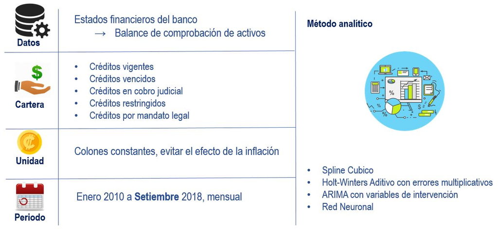

## Resultados

### Serie de la cartera crediticia

#### Análisis Descriptivo

```r
datos <- read.csv("Serie_Cartera_Crediticia2.csv",sep = ";")

datos$Mes<-as.Date(as.character(datos$Mes), format = "%d/%m/%Y")


s.banco1 <- ts(datos$banco1, frequency=12, start=c(2010,1),end = c(2018,9))
s.banco2 <- ts(datos$banco2, frequency=12, start=c(2010,1),end = c(2018,9))
s.banco3 <- ts(datos$banco3, frequency=12, start=c(2010,1),end = c(2018,9))


hchart(s.banco1,name = "Banco 1")%>%
  hc_add_series(name = "Banco 2",s.banco2, color="greenyellow")%>%
  hc_add_series(name = "Banco 3",s.banco3, color="cadetblue")%>%
  hc_title(text = "Cartera Crediticia de Enero 2010 a Setiembre 2018 según banco <br> (Millones de colones) ",
           margin = 20, align = "center",
           style = list(color = "#black", useHTML = TRUE, fontWeight = "bold")) %>%
  hc_subtitle(text = "Millones de colones",
              align = "center")%>%
  hc_yAxis(title = list(text = "Colones"),
           labels = list(format = "{value}"))%>%
  hc_size(width = 800,height=600)%>%
  hc_tooltip(crosshairs = T,valueDecimals = 1)%>%
  hc_chart(
        zoomType = "xy"
      )
```

[interactive chart not shown]

Elaboración con datos de Superintendencia General de Entidades Financieras (SUGEF) 2010 a 2018

#### Descomposición de la serie

Bancos privados costarricenses:

##### Banco 1

```r
# Banco 1
x <- stl(s.banco1,t.window=13, s.window="periodic", robust=TRUE)

sea<-x$time.series[,1]
tre<-x$time.series[,2]
irreg<-x$time.series[,3]

titulo<-hchart(s.banco1,color="white",showInLegend = FALSE)%>%
  hc_title(text = "Banco 1",
           margin = 20, align = "center",
           style = list(color = "#black", useHTML = TRUE, fontWeight = "bold")) %>%
  hc_subtitle(text = "Millones de colones",
              align = "center") %>% hc_add_theme(hc_theme_null()) %>%
  hc_size(width = 500, height = 75)

serie<-hchart(s.banco1,color="orange") %>% hc_yAxis(title= list(text = "Cartera"),
           labels = list(format = "{value}"))%>%
  hc_size(width = 500, height = 175)
estac<-hchart(sea,color="deeppink") %>% hc_yAxis(title= list(text = "Estacionalidad"),
           labels = list(format = "{value}"))%>%
  hc_size(width = 500, height = 175)
tend<-hchart(tre,color="darkturquoise") %>% hc_yAxis(title= list(text = "Tendencia"),
           labels = list(format = "{value}"))%>%
  hc_size(width = 500, height = 175)
irregu<-hchart(irreg,color="greenyellow",type="column") %>% hc_yAxis(title= list(text = "Irregularidad"),
           labels = list(format = "{value}"))%>%
  hc_size(width = 500, height = 175)

hw_grid(titulo,
        serie,
          estac,
          tend,
          irregu, ncol = 1)
```

[interactive chart not shown]

Elaboración con datos de Superintendencia General de Entidades Financieras (SUGEF) 2010 a 2018